# Assignment 2

Rajesh Dhungna

2023-10-14

install.packages(“dplyr”) install.packages(“tidyr”) install.packages(“lubridate”) install.packages(“ggplot2”) install.packages(“corrplot”)

```r
library(dplyr)
library(tidyr)
library(lubridate)
```

```r
library(ggplot2)
library(corrplot)
```

Task 1

```r
#Loading Studentmarks dataset into sdf dataframe

sdf <- read.csv("Studentmarks.csv",header=TRUE)
head(sdf)
```

```
##   StudentID Studentname        dob X2020 X2021 X2022
## 1         1        Anna 12/12/1998    75    78    85
## 2         2       James 10/08/1999    65    74    52
## 3         3        Mary 21/08/1998    56    68    90
## 4         4      Antony 02/05/1999    78    65    85
## 5         5       Jacob 22/07/1998    85    78    65
## 6         6     Angelin 11/05/1998    65    68    70
```

```r
#Shape of dataframe
dim(sdf)
```

```
## [1] 10  6
```

```r
#Structure of dataframe
str(sdf)
```

```
## 'data.frame':    10 obs. of  6 variables:
##  $ StudentID  : int  1 2 3 4 5 6 7 8 9 10
##  $ Studentname: chr  "Anna" "James" "Mary" "Antony" ...
##  $ dob        : chr  "12/12/1998" "10/08/1999" "21/08/1998" "02/05/1999" ...
##  $ X2020      : int  75 65 56 78 85 65 78 77 90 95
##  $ X2021      : int  78 74 68 65 78 68 52 72 87 85
##  $ X2022      : int  85 52 90 85 65 70 88 75 88 75
```

```r
#Checking for NA value
any(is.na(sdf))
```

```
## [1] FALSE
```

```r
#Exploring the summary of dataframe
summary(sdf)
```

```
##    StudentID     Studentname            dob                X2020
##  Min.   : 1.00   Length:10          Length:10          Min.   :56.00
##  1st Qu.: 3.25   Class :character   Class :character   1st Qu.:67.50
##  Median : 5.50   Mode  :character   Mode  :character   Median :77.50
##  Mean   : 5.50                                         Mean   :76.40
##  3rd Qu.: 7.75                                         3rd Qu.:83.25
##  Max.   :10.00                                         Max.   :95.00
##      X2021          X2022
##  Min.   :52.0   Min.   :52.00
##  1st Qu.:68.0   1st Qu.:71.25
##  Median :73.0   Median :80.00
##  Mean   :72.7   Mean   :77.30
##  3rd Qu.:78.0   3rd Qu.:87.25
##  Max.   :87.0   Max.   :90.00
```

```r
#Creating a new column o_dob
sdf$o_dob <- sdf$dob
```

a.Caluclating the age of student into new colum age1

```r
#changing the datatype of dob to Date
sdf$dob <- as.Date(sdf$dob, format="%d/%m/%Y")
```

```r
#Creating new column age1 by take the difference between current date and dob column
sdf$age1 <- difftime(Sys.Date(), sdf$dob)
```

We got the difference in days. So we can calculate the year by dividing days by 365.

```r
#First changing age1 as numeric datatype and dividing age1 by 365 and rounding to nearest integer
sdf$age1 <- round(as.numeric(sdf$age1)/365)
```

```r
#Checking our dataframe sdf for new column age1
head(sdf)
```

```
##   StudentID Studentname        dob X2020 X2021 X2022      o_dob age1
## 1         1        Anna 1998-12-12    75    78    85 12/12/1998   25
## 2         2       James 1999-08-10    65    74    52 10/08/1999   24
## 3         3        Mary 1998-08-21    56    68    90 21/08/1998   25
## 4         4      Antony 1999-05-02    78    65    85 02/05/1999   24
## 5         5       Jacob 1998-07-22    85    78    65 22/07/1998   25
## 6         6     Angelin 1998-05-11    65    68    70 11/05/1998   25
```

b.Splitting the original dob column into date, month and year and calculating the age2 based on year column only.

```r
#Separating the o_dob into date, month and year column
sdf <- separate(sdf,o_dob, c("date", "month", "year"), sep="/")
```

```r
#changing year colum into numeric datatype
sdf$year <- as.numeric(sdf$year)
```

```r
#Calculating the current year
current_year <- year(Sys.Date())
```

```r
#Creating a new column age2 by taking the difference between current_year and year column
sdf <- mutate(sdf, year, age2=current_year-year)
```

c.Scatter plot for Stuent name versus Marks for all three years

```r
#Lets gather our marks by years into separate column academci_year
marks_df <- gather(sdf,key=academic_year,value=mark,c("X2020","X2021","X2022"))
```

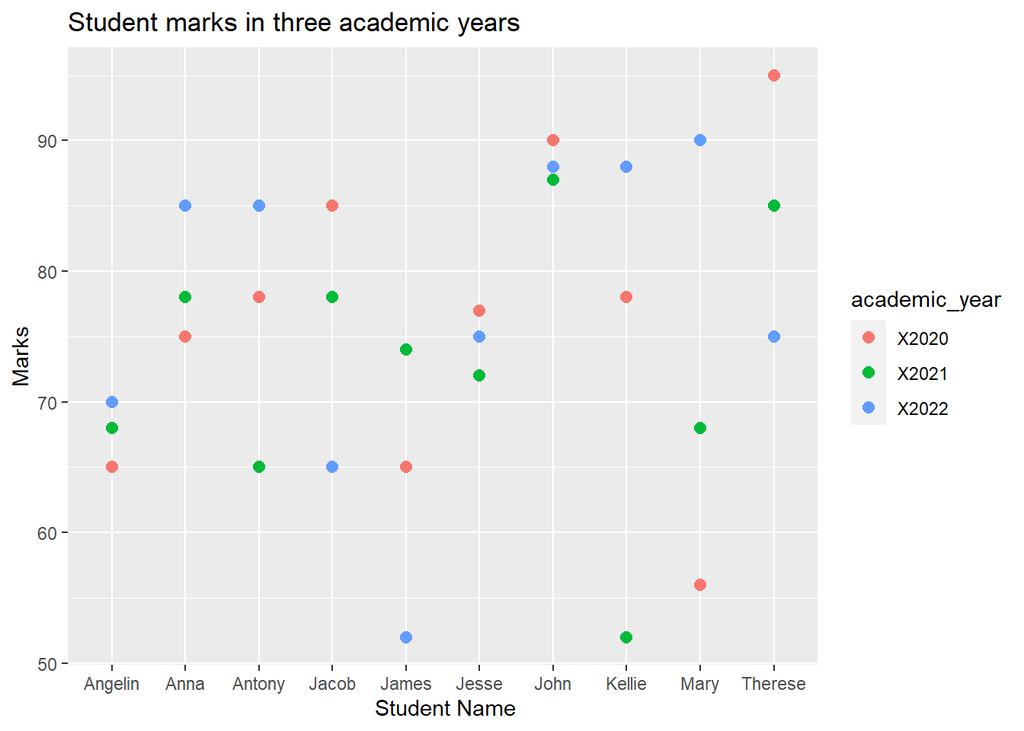

```r
#Plotting the data
ggplot(marks_df, aes(x=Studentname, y=mark, fill=academic_year,group=academic_year, color=academic_year))+
geom_point(size=2.5)+
labs(title ="Student marks in three academic years",x = " Student Name", y = "Marks")
```

d.Calculating the total marks for each students

```r
#Calculating the total marks
sdf$total_marks <- (sdf$X2020+sdf$X2021+sdf$X2022)
```

filtering those who got atleast 200 marks.

```r
#Creating a new dataframe with marks atleast 200
filter_marks <- filter(sdf,total_marks>=200)
```

Rearranging the dataframe in descending order based on total marks

```r
#Sorting value based on total_marks
filter_marks <- arrange(filter_marks, desc(total_marks))
```

Plotting a bar chart for total_marks vs Studentname in descending order

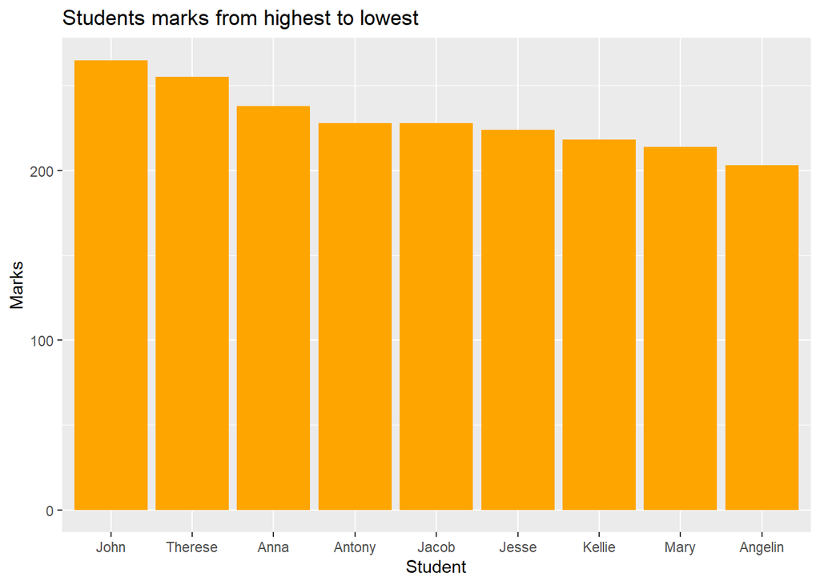

```r
#Bar chart for students vs totalmarks

ggplot(filter_marks, aes(x=reorder(Studentname, total_marks, decreasing= TRUE), y= total_marks)) +
  geom_bar(stat="identity", fill="orange") +
  labs(title = "Students marks from highest to lowest", x = "Student", y = "Marks")
```

Task 2 Working with movies data

```r
#Importing data into movie_df dataframe
movie_df <- read.csv("Movies.csv")
```

```r
#Checking the first five rows
head(movie_df)
```

```
##   Color          Director Reviews Duration Director_facebook_likes
## 1 Color     James Cameron     723      178                       0
## 2 Color    Gore Verbinski     302      169                     563
## 3 Color        Sam Mendes     602      148                       0
## 4 Color Christopher Nolan     813      164                   22000
## 5 Color    Andrew Stanton     462      132                     475
## 6 Color         Sam Raimi     392      156                       0
##   Actor_3_facebook_likes     Actor_2_name Actor_1_facebook_likes     Gross
## 1                    855 Joel David Moore                   1000 760505847
## 2                   1000    Orlando Bloom                  40000 309404152
## 3                    161     Rory Kinnear                  11000 200074175
## 4                  23000   Christian Bale                  27000 448130642
## 5                    530  Samantha Morton                    640  73058679
## 6                   4000     James Franco                  24000 336530303
##    Genre    Actor_1_name                                     Title   Votes
```

[output cut: 41 more lines]

```r
#Checking the dimension of dataframe
dim(movie_df)
```

```
## [1] 3891   26
```

```r
#Checking for structure of each attribute
str(movie_df)
```

```
## 'data.frame':    3891 obs. of  26 variables:
##  $ Color                    : chr  "Color" "Color" "Color" "Color" ...
##  $ Director                 : chr  "James Cameron" "Gore Verbinski" "Sam Mendes" "Christopher Nolan" ...
##  $ Reviews                  : int  723 302 602 813 462 392 324 635 375 673 ...
##  $ Duration                 : int  178 169 148 164 132 156 100 141 153 183 ...
##  $ Director_facebook_likes  : int  0 563 0 22000 475 0 15 0 282 0 ...
##  $ Actor_3_facebook_likes   : int  855 1000 161 23000 530 4000 284 19000 10000 2000 ...
##  $ Actor_2_name             : chr  "Joel David Moore" "Orlando Bloom" "Rory Kinnear" "Christian Bale" ...
##  $ Actor_1_facebook_likes   : int  1000 40000 11000 27000 640 24000 799 26000 25000 15000 ...
##  $ Gross                    : int  760505847 309404152 200074175 448130642 73058679 336530303 200807262 458991599 301956980 330249062 ...
##  $ Genre                    : chr  "Action" "Action" "Action" "Action" ...
##  $ Actor_1_name             : chr  "CCH Pounder" "Johnny Depp" "Christoph Waltz" "Tom Hardy" ...
##  $ Title                    : chr  "Avatara" "Pirates of the Caribbean: At World's Enda" "Spectrea" "The Dark Knight Risesa" ...
##  $ Votes                    : int  886204 471220 275868 1144337 212204 383056 294810 462669 321795 371639 ...
##  $ Cast_total_facebook_likes: int  2791 46563 11554 95000 2277 39000 1651 66000 46282 21000 ...
##  $ Actor_3_name             : chr  "Wes Studi" "Jack Davenport" "Stephanie Sigman" "Joseph Gordon-Levitt" ...
##  $ Facenumber_in_poster     : int  0 0 1 0 1 0 1 4 3 0 ...
##  $ Plot_keywords            : chr  "avatar|future|marine|native|paraplegic" "goddess|marriage ceremony|marriage proposal|pirate|singapore" "bomb|espionage|sequel|spy|terrorist" "deception|imprisonment|lawlessness|police officer|terrorist plot" ...
##  $ Movie_imdb_link          : chr  "http://www.imdb.com/title/tt0499549/?ref_=fn_tt_tt_1" "http://www.imdb.com/title/tt0449088/?ref_=fn_tt_tt_1" "http://www.imdb.com/title/tt2379713/?ref_=fn_tt_tt_1" "http://www.imdb.com/title/tt1345836/?ref_=fn_tt_tt_1" ...
##  $ Language                 : chr  "English" "English" "English" "English" ...
##  $ Content_rating           : chr  "PG-13" "" "PG-13" "PG-13" ...
##  $ Budget                   : num  2.37e+08 3.00e+08 2.45e+08 2.50e+08 2.64e+08 ...
##  $ Year                     : int  2009 2007 2015 2012 2012 2007 2010 2015 2009 2016 ...
##  $ Actor_2_facebook_likes   : int  936 5000 393 23000 632 11000 553 21000 11000 4000 ...
##  $ Imdb_score               : num  7.9 7.1 6.8 8.5 6.6 6.2 7.8 7.5 7.5 6.9 ...
##  $ Aspect_ratio             : num  1.78 2.35 2.35 2.35 2.35 2.35 1.85 2.35 2.35 2.35 ...
##  $ Movie_facebook_likes     : int  33000 0 85000 164000 24000 0 29000 118000 10000 197000 ...
```

```r
#Checking for na values
any(is.na(movie_df))
```

```
## [1] TRUE
```

```r
#Total number of na in dataframe
sum(is.na(movie_df))
```

```
## [1] 101
```

```r
#Exploring the summary of movie_df
summary(movie_df)
```

```
##     Color             Director            Reviews          Duration
##  Length:3891        Length:3891        Min.   :  1.00   Min.   : 34.0
##  Class :character   Class :character   1st Qu.: 72.25   1st Qu.: 95.0
##  Mode  :character   Mode  :character   Median :134.00   Median :106.0
##                                        Mean   :163.23   Mean   :109.9
##                                        3rd Qu.:221.75   3rd Qu.:120.0
##                                        Max.   :813.00   Max.   :330.0
##                                        NA's   :1        NA's   :1
##  Director_facebook_likes Actor_3_facebook_likes Actor_2_name
##  Min.   :    0.0         Min.   :    0.0        Length:3891
##  1st Qu.:   10.0         1st Qu.:  183.0        Class :character
##  Median :   58.0         Median :  427.0        Mode  :character
##  Mean   :  781.3         Mean   :  753.5
##  3rd Qu.:  226.0         3rd Qu.:  687.0
##  Max.   :23000.0         Max.   :23000.0
##                          NA's   :10
##  Actor_1_facebook_likes     Gross              Genre
##  Min.   :     0.0       Min.   :      162   Length:3891
##  1st Qu.:   721.8       1st Qu.:  6836508   Class :character
##  Median :  1000.0       Median : 27979400   Mode  :character
##  Mean   :  7584.7       Mean   : 51054995
##  3rd Qu.: 12000.0       3rd Qu.: 65360661
##  Max.   :640000.0       Max.   :760505847
##  NA's   :3
##  Actor_1_name          Title               Votes
##  Length:3891        Length:3891        Min.   :      5
##  Class :character   Class :character   1st Qu.:  17314
##  Mode  :character   Mode  :character   Median :  50415
##                                        Mean   : 102583
##                                        3rd Qu.: 124204
##                                        Max.   :1689764
##
##  Cast_total_facebook_likes Actor_3_name       Facenumber_in_poster
##  Min.   :     0            Length:3891        Min.   : 0.00
##  1st Qu.:  1580            Class :character   1st Qu.: 0.00
##  Median :  2886            Mode  :character   Median : 1.00
##  Mean   : 11080                               Mean   : 1.38
##  3rd Qu.: 15672                               3rd Qu.: 2.00
##  Max.   :655285                               Max.   :43.00
##                                               NA's   :6
```

[output cut: 9 more lines]

```
##  Min.   :2.180e+02   Min.   :1920   Min.   :     0         Min.   :1.600
##  1st Qu.:1.000e+07   1st Qu.:1999   1st Qu.:   363         1st Qu.:5.900
##  Median :2.400e+07   Median :2005   Median :   664         Median :6.600
##  Mean   :4.521e+07   Mean   :2003   Mean   :  1971         Mean   :6.464
##  3rd Qu.:5.000e+07   3rd Qu.:2010   3rd Qu.:   971         3rd Qu.:7.200
##  Max.   :1.222e+10   Max.   :2016   Max.   :137000         Max.   :9.300
##                                     NA's   :5
##   Aspect_ratio   Movie_facebook_likes
##  Min.   : 1.18   Min.   :     0
##  1st Qu.: 1.85   1st Qu.:     0
##  Median : 2.35   Median :   209
##  Mean   : 2.11   Mean   :  9138
##  3rd Qu.: 2.35   3rd Qu.: 11000
##  Max.   :16.00   Max.   :349000
##  NA's   :75
```

1. Dealing with missing values

```r
#Checking each columns for missing values
sapply(movie_df, function(x) length(which(x=="")))
```

```
##                     Color                  Director                   Reviews
##                         2                         0                         0
##                  Duration   Director_facebook_likes    Actor_3_facebook_likes
##                         0                         0                         0
##              Actor_2_name    Actor_1_facebook_likes                     Gross
##                         5                         0                         0
##                     Genre              Actor_1_name                     Title
##                         0                         3                         0
##                     Votes Cast_total_facebook_likes              Actor_3_name
##                         0                         0                        10
##      Facenumber_in_poster             Plot_keywords           Movie_imdb_link
##                         0                        31                         0
##                  Language            Content_rating                    Budget
##                         0                        74                         0
##                      Year    Actor_2_facebook_likes                Imdb_score
##                         0                         0                         0
##              Aspect_ratio      Movie_facebook_likes
##                         0                         0
```

```r
#Lets create a function to extract dimension  for each missing values
missing_index <- function(x) which(x=="", arr.ind = TRUE)
i <- missing_index(movie_df)
```

```r
#Replacing all missing values with NA
movie_df[i] <- NA
```

```r
#Lets verify for any missing values
sapply(movie_df, function(x) length(which(x=="")))
```

```
##                     Color                  Director                   Reviews
##                         0                         0                         0
##                  Duration   Director_facebook_likes    Actor_3_facebook_likes
##                         0                         0                         0
##              Actor_2_name    Actor_1_facebook_likes                     Gross
##                         0                         0                         0
##                     Genre              Actor_1_name                     Title
##                         0                         0                         0
##                     Votes Cast_total_facebook_likes              Actor_3_name
##                         0                         0                         0
##      Facenumber_in_poster             Plot_keywords           Movie_imdb_link
##                         0                         0                         0
##                  Language            Content_rating                    Budget
##                         0                         0                         0
##                      Year    Actor_2_facebook_likes                Imdb_score
##                         0                         0                         0
##              Aspect_ratio      Movie_facebook_likes
##                         0                         0
```

Now that we have changed our missing value to NA, the total NA will increase in our dataframe. First lets explore the columns which have NA values again.

```r
sapply(movie_df, function(x) sum(is.na(x)))
```

```
##                     Color                  Director                   Reviews
##                         2                         0                         1
##                  Duration   Director_facebook_likes    Actor_3_facebook_likes
##                         1                         0                        10
##              Actor_2_name    Actor_1_facebook_likes                     Gross
##                         5                         3                         0
##                     Genre              Actor_1_name                     Title
##                         0                         3                         0
##                     Votes Cast_total_facebook_likes              Actor_3_name
##                         0                         0                        10
##      Facenumber_in_poster             Plot_keywords           Movie_imdb_link
##                         6                        31                         0
##                  Language            Content_rating                    Budget
##                         0                        74                         0
##                      Year    Actor_2_facebook_likes                Imdb_score
##                         0                         5                         0
##              Aspect_ratio      Movie_facebook_likes
##                        75                         0
```

Based on our dataset, I have decided to remove the following columns which have less influence on our target variable profit.

1.Title: Since we are interested in finding the influential factor for the profit and each movie has unique title. Hence the title may not be appropriate profit indicator in this case.

2. Color: Most of the value for Color attribute are color so this will provide less variability in our dataset.
3. Language: All the language value in our dataset are English, hence it can be less contributor to profit.
4. Year: Since this attribute is not a continuous variable and needs separate analysis using time series method, I am excluding this column in this analysis.
5. Plot_keywords: This attribute might not be relevant in deciding the profit.
6. Movie_imdb_link : This attribute might not be relevant in deciding the profit.

```r
#Lets create a dataframe without these columns
m_df1 <- select(movie_df,-c(Title, Color, Language, Year, Movie_imdb_link,Plot_keywords ))
```

Since every movie has unique value for each attributes that cannot be assumed. If we impute these NA values using mode for categorical values and mean for numeric values then there is a chances that a particular movie could have high profit or rated high based on these value. Hence, I have decided to omit all the row which has NA value.

```r
#Lets create a new data frame without NA value
m_df <- na.omit(m_df1)
```

```r
#Verifying for no NA in dataset
any(is.na(m_df))
```

```
## [1] FALSE
```

2. Exploration part

bi.

```r
#Lets calculate the profit
m_df$profit <- m_df$Gross-m_df$Budget
```

Before plotting the data lets normalize our dataset to bring them to same scale of 0 to 1 using min-max scaler. This will make our data consistent and easy to visualize since all the value will be converge to same scale.

```r
#Defining normalization function
minmax_scale <- function(x){
  (x-min(x))/(max(x)-min(x))
}
```

Since the normalization function cannot take categorical columns as argument we must have separate dataframe with numeric value only. First lets create a dataframe which consist of numeric value only.

```r
#Filtering column with numeric datatype from our dataset
num_m_df <- m_df[, sapply(m_df,is.numeric)]
```

Now we can call normalization function on our new dataframe num_m_df.

```r
#Normalized dataframe
nor_m_df <- as.data.frame(sapply(num_m_df,minmax_scale))
```

Now we are ready to plot our data and see the relationship using regression line.

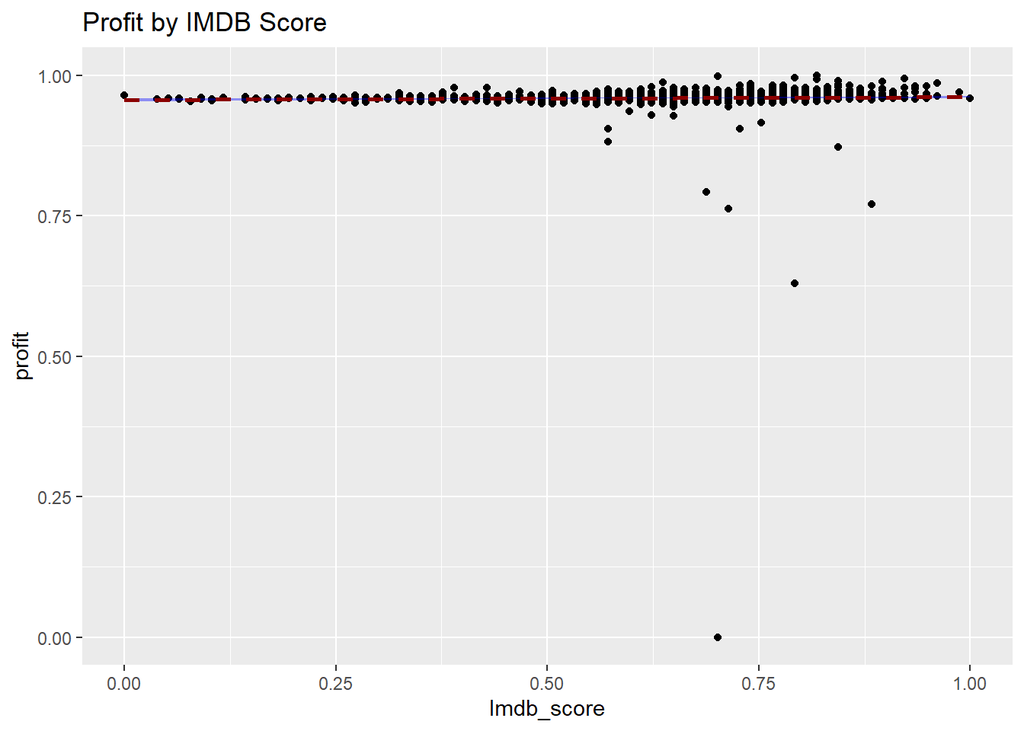

```r
#scatter plot between profit and Imdb_score
ggplot(nor_m_df, aes(y=profit,x=Imdb_score)) + geom_point()+  ggtitle("Profit by IMDB Score") + geom_smooth(method=lm,  linetype="dashed", color="darkred", fill="blue")
```

From the above graph we can see that there is weak correlation among Imdb_score and profit.

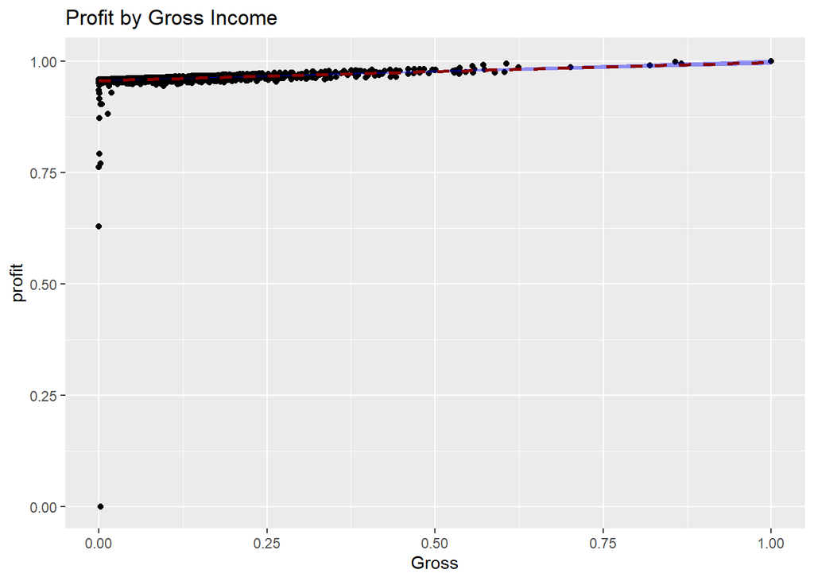

```r
#scatter plot between profit and Gross
ggplot(nor_m_df, aes(y=profit,x=Gross)) + geom_point()+  ggtitle("Profit by Gross Income") + geom_smooth(method=lm,  linetype="dashed", color="darkred", fill="blue")
```

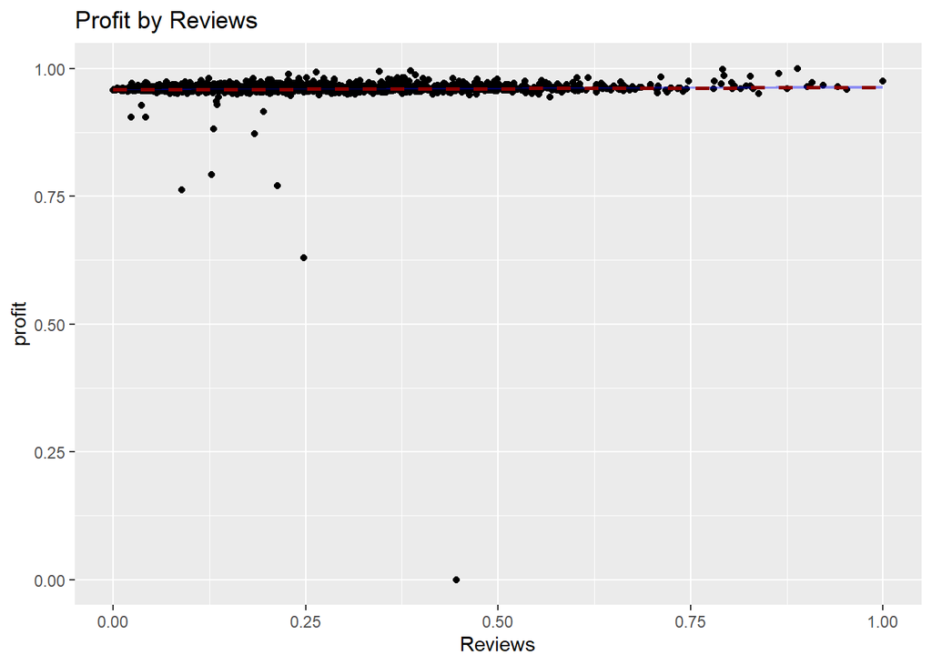

```r
#scatter plot between profit and Reviews
ggplot(nor_m_df, aes(y=profit,x=Reviews)) + geom_point()+  ggtitle("Profit by Reviews") + geom_smooth(method=lm,  linetype="dashed", color="darkred", fill="blue")
```

From the above graph we can see that there is weak correlation among review and profit.

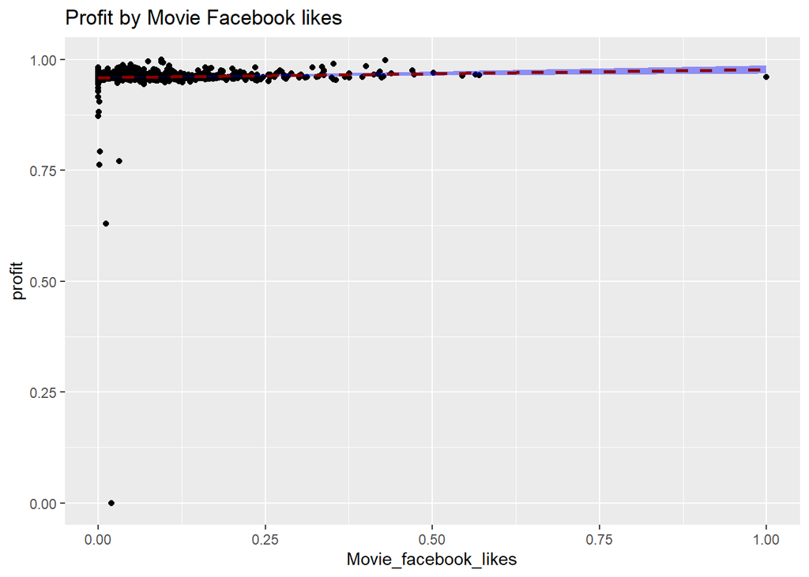

```r
#scatter plot between profit and Movie Facebook likes
ggplot(nor_m_df, aes(y=profit,x=Movie_facebook_likes)) + geom_point()+  ggtitle("Profit by Movie Facebook likes") + geom_smooth(method=lm,  linetype="dashed", color="darkred", fill="blue")
```

2. Correlation between the variables. Since our variables are mixed type(ordinal and nominal), I have used kendall method to calculate the correlation

```r
#Calculating the correlation between variables
cor_d <- cor(nor_m_df, method="kendall")
```

```r
#Lets rename our columns to make our visualization better
colnames(cor_d) <- c("reviews","duration", "dir_fb_l","act3_fb_l","act1_fb_l","gross","votes","cast_fb_l","p_face_no","budget","act2_fb_l","imdb_scr","asp_r","m_fb_l","profit")
rownames(cor_d) <- c("reviews","duration", "dir_fb_l","act3_fb_l","act1_fb_l","gross","votes","cast_fb_l","p_face_no","budget","act2_fb_l","imdb_scr","asp_r","m_fb_l","profit")
```

```r
#Lets make the copy of our correlation matrix
cor_d1 <- cor_d
```

```r
#Lets set the diagonal correlation coefficient value to NA which is correlation with self.
diag(cor_d1) <- NA
```

```r
#Lets change our matrix to dataframe
cor_df <- as.data.frame(cor_d1)
```

```r
#Listing the maximum positive correlation coefficient between profit and other variable
max(cor_df$profit, na.rm= TRUE)
```

```
## [1] 0.4500739
```

```r
#Finding the index of this value
which(cor_df==max(cor_df$profit, na.rm= TRUE), arr.ind = TRUE)
```

```
##        row col
## profit  15   6
## gross    6  15
```

```r
#Listing maximum negative correlation
min(cor_df$profit, na.rm= TRUE)
```

```
## [1] -0.1026907
```

```r
#Finding the index of this value
which(cor_df==min(cor_df$profit, na.rm= TRUE), arr.ind = TRUE)
```

```
##        row col
## profit  15  10
## budget  10  15
```

Lets visualize our result in graph

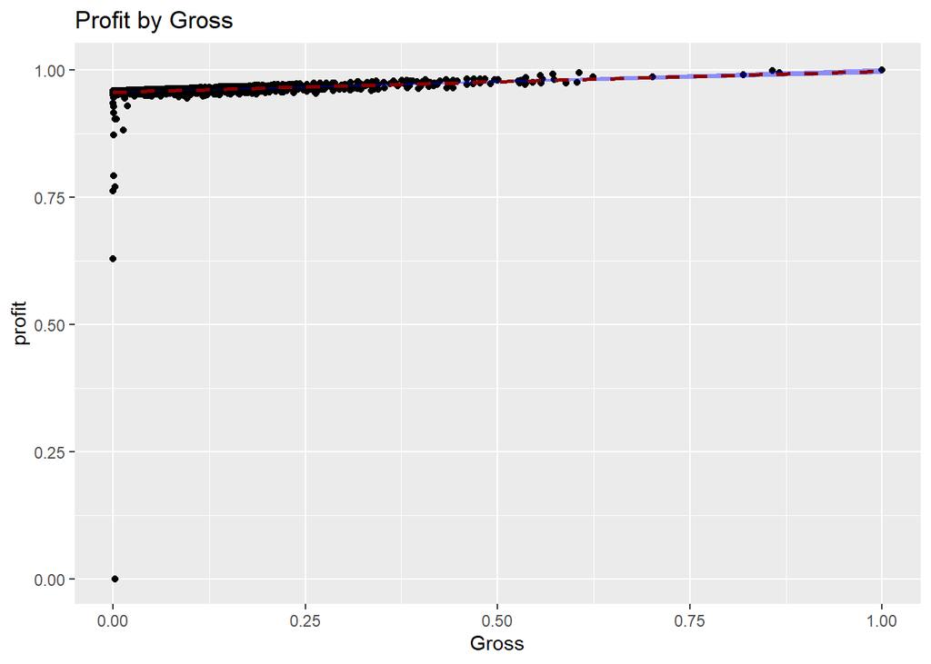

```r
#scatter plot between profit and Budget
ggplot(nor_m_df, aes(y=profit,x=Gross)) + geom_point()+  ggtitle("Profit by Gross") + geom_smooth(method=lm,  linetype="dashed", color="darkred", fill="blue")
```

From above two result the maximum positive correlation is between profit and gross with the value of 0.45 and maximum negative correlation is between profit and budget with the value of -0.1.

It is obvious that higher the gross income of the movie higher the profit which is also shown by our result. Hence if we want to increase the profit we must explore the variables that have influence on the gross sales to name few Director, Actor1 etc.

```r
#Listing the minimum correlation
min(abs(cor_df$profit), na.rm= TRUE)
```

```
## [1] 0.004529327
```

```r
#Finding the index of this value

which(cor_df==min(abs(cor_df$profit), na.rm= TRUE), arr.ind = TRUE)
```

```
##          row col
## profit    15   2
## duration   2  15
```

So the weakest correlation between profit is with duration of movie with the value of 0.0045.

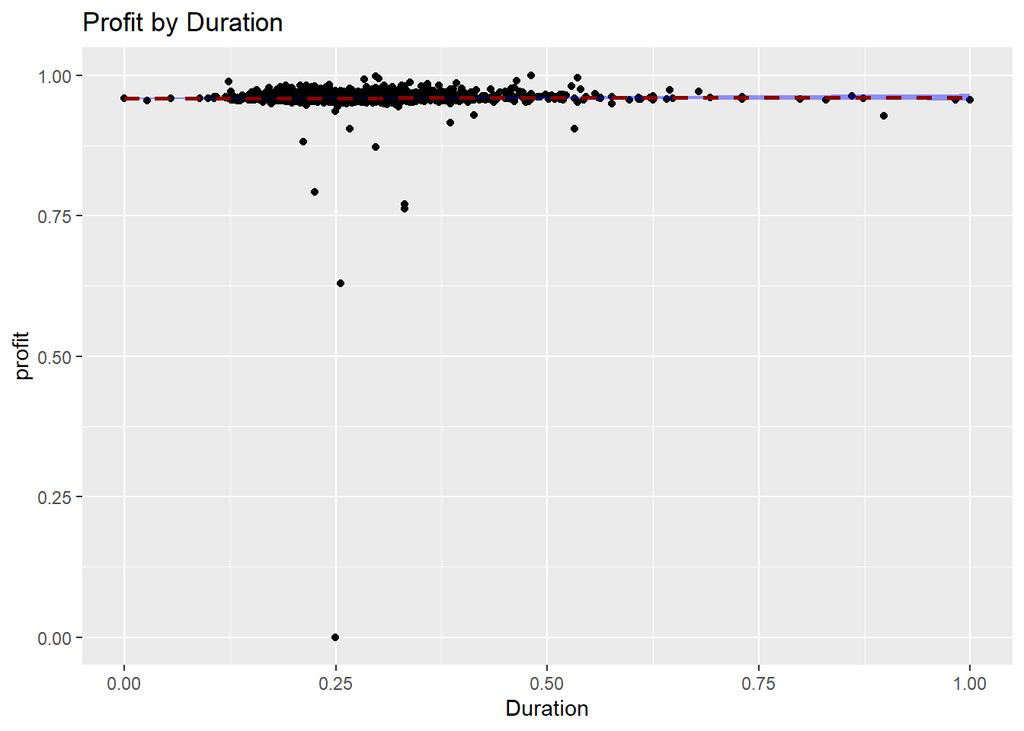

```r
#Lets see a line graph between profit and duration
#scatter plot between profit and duration
ggplot(nor_m_df, aes(y=profit,x=Duration)) + geom_point()+  ggtitle("Profit by Duration") + geom_smooth(method=lm,  linetype="dashed", color="darkred", fill="blue")
```

From the above result we see that the duration of the movie has very less impact on the profit. This may be because most of the value lies below the range of 120 minutes which cause minimal effect on profit.

```r
summary(m_df$Duration)
```

```
##    Min. 1st Qu.  Median    Mean 3rd Qu.    Max.
##    37.0    96.0   106.0   110.2   120.0   330.0
```

Lets plot the correlation coefficient for all the variable that we have used in our analysis.

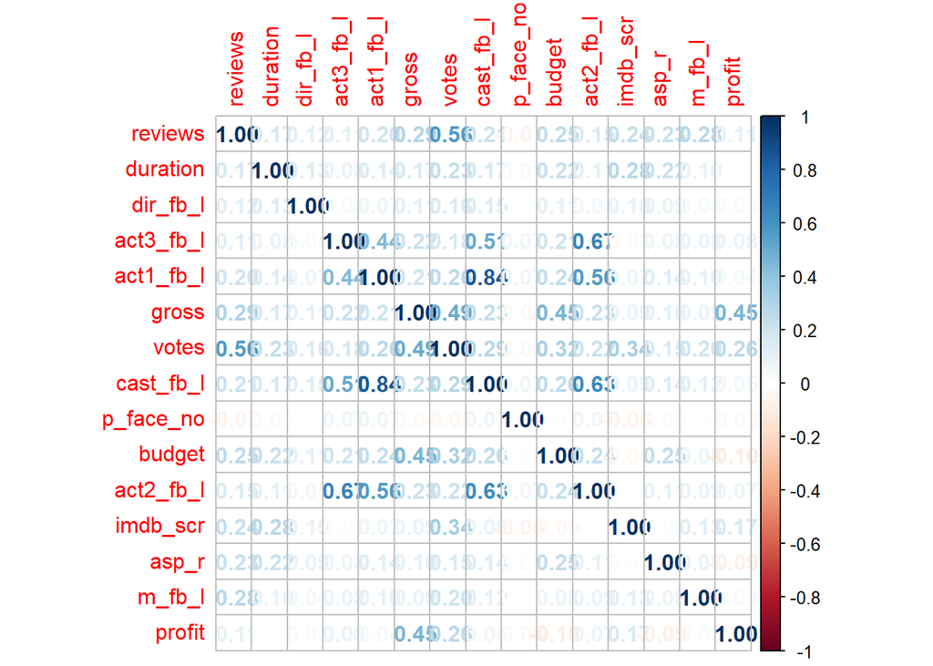

```r
#Correlation Matrix plot
corrplot(cor_d,method="number")
```

```r
#Lets explore the value of maximum correlation coefficient in our study
max(abs(cor_df), na.rm= TRUE)
```

```
## [1] 0.8419219
```

```r
#Index of maximum corelation
which(cor_df==max(abs(cor_df), na.rm= TRUE), arr.ind = TRUE)
```

```
##           row col
## cast_fb_l   8   5
## act1_fb_l   5   8
```

This value is for the cast_facebook_likes and actor1_facebook_likes. We can interpret this result as if a lead actor of the movie have higher facebook like than the overall cast of the movie will get higher likes.

```r
#Lets explore the value of minimum correlation coefficient in our study
min_correlation <- min(abs(cor_df), na.rm= TRUE)
min_correlation
```

```
## [1] 0.002067434
```

If we search our correlation matrix this value matches -0.002067434 with number of faces on poster and movie likes on facebook. Hence we can say that there is very weak relation between Facebook like for a movie based on number of faces on poster.

We can also visualize our correlation result using corrplot with square method for better visualization.

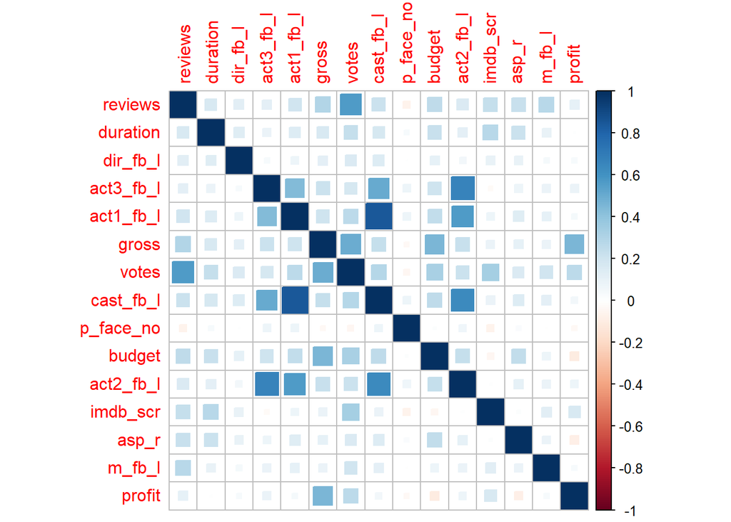

```r
#Correlation Matrix plot
corrplot(cor_d,method="square")
```